# Session 1

## Transformation

We will learn some functions that help transform our data.

### mutate()

The mutate() adds new variables and preserves existing ones. Syntax: mutate(data.frame, new_column_1 = calculation_1, new_column_2 = calculation_2, …)

```r
women <- mutate(women, height_inch = height_cm / 2.54)
women
```

```
## # A tibble: 15 × 5
##    name      city_province weight_kg height_cm height_inch
##    <chr>     <chr>             <dbl>     <dbl>       <dbl>
##  1 Olivia    Vancouver, BC        18       115        45.3
##  2 Emma      Vancouver, BC        19       117        46.1
##  3 Charlotte Vancouver, BC        60        NA        NA
##  4 Amelia    Vancouver, BC        31       123        48.4
##  5 Ava       Vancouver, BC        32        NA        NA
##  6 Sophia    Edmonton, AB         33       129        50.8
##  7 Isabella  Edmonton, AB         34       132        52.0
##  8 Mia       Edmonton, AB         65        NA        NA
##  9 Evelyn    Toronto, ON          26       139        54.7
## 10 Harper    Toronto, ON          67       142        55.9
## 11 Luna      Toronto, ON          68       146        57.5
## 12 Camila    Toronto, ON          69       150        59.1
## 13 Gianna    Ottawa, ON           70       154        60.6
## 14 Elizabeth Ottawa, ON           71       159        62.6
## 15 Eleanor   Ottawa, ON           72       164        64.6
```

```r
# mutate and add the new column as the last column. You can change the place by .before or .after arguments.
women <- mutate(women, weight_lbs = weight_kg / 2.2, .after = weight_kg)
women
```

```
## # A tibble: 15 × 6
##    name      city_province weight_kg weight_lbs height_cm height_inch
##    <chr>     <chr>             <dbl>      <dbl>     <dbl>       <dbl>
##  1 Olivia    Vancouver, BC        18       8.18       115        45.3
##  2 Emma      Vancouver, BC        19       8.64       117        46.1
##  3 Charlotte Vancouver, BC        60      27.3         NA        NA
##  4 Amelia    Vancouver, BC        31      14.1        123        48.4
##  5 Ava       Vancouver, BC        32      14.5         NA        NA
##  6 Sophia    Edmonton, AB         33      15          129        50.8
##  7 Isabella  Edmonton, AB         34      15.5        132        52.0
##  8 Mia       Edmonton, AB         65      29.5         NA        NA
##  9 Evelyn    Toronto, ON          26      11.8        139        54.7
## 10 Harper    Toronto, ON          67      30.5        142        55.9
## 11 Luna      Toronto, ON          68      30.9        146        57.5
## 12 Camila    Toronto, ON          69      31.4        150        59.1
## 13 Gianna    Ottawa, ON           70      31.8        154        60.6
## 14 Elizabeth Ottawa, ON           71      32.3        159        62.6
## 15 Eleanor   Ottawa, ON           72      32.7        164        64.6
```

### ifelse()

The ifelse() is a shorthand vectorised alternative to the standard if…else statement. Syntax: ifelse(test_expression, x, y)

```r
num_vec <- c(1:10)
result <- ifelse( num_vec %% 2 == 0, "even", "odd" )
names(result) <- c(1:10)
result
```

```
##      1      2      3      4      5      6      7      8      9     10
##  "odd" "even"  "odd" "even"  "odd" "even"  "odd" "even"  "odd" "even"
```

You can use it with mutate().

```r
women <- mutate(women, is_bmi_normal = ifelse(((18.5 <= weight_lbs/(height_inch ^ 2))
                                               & (weight_lbs/(height_inch ^ 2) <= 24.9)), "normal", "not normal"))
```

### case_when()

The case_when() is an alternative to an ifelse(). You can use multiple if else statements whenever you need to use them. Syntax: case_when(conditional_statement1 ~ x, conditional_statement2 ~ y, …)

```r
num_vec <- c(0:10)

result <- case_when(num_vec == 0 ~ "zero",
                    num_vec %% 2 == 0 ~ "even",
                    TRUE ~ "odd") # TRUE means if not all above conditions are equal to TRUE, so set "odd" as the value
names(result) <- c(0:10)
result
```

```
##      0      1      2      3      4      5      6      7      8      9     10
## "zero"  "odd" "even"  "odd" "even"  "odd" "even"  "odd" "even"  "odd" "even"
```

You can use it with mutate().

```r
women <- mutate(women, bmi = case_when(weight_kg/height_cm/height_cm*10000 >= 30 ~ "obesity",
                                      weight_kg/height_cm/height_cm*10000 >= 25 &
                                      weight_kg/height_cm/height_cm*10000 < 30 ~ "overweight",
                                      weight_kg/height_cm/height_cm*10000 < 25 &
                                      weight_kg/height_cm/height_cm*10000 >= 18.5 ~ "normal",
                                      weight_kg/height_cm/height_cm*10000 < 18.5 ~ "underweight"
                                      )
                )
women
```

```
## # A tibble: 15 × 8
##    name      city_province weight_kg weight_lbs height_cm height…¹ is_bm…² bmi
##    <chr>     <chr>             <dbl>      <dbl>     <dbl>    <dbl> <chr>   <chr>
##  1 Olivia    Vancouver, BC        18       8.18       115     45.3 not no… unde…
##  2 Emma      Vancouver, BC        19       8.64       117     46.1 not no… unde…
##  3 Charlotte Vancouver, BC        60      27.3         NA     NA   <NA>    <NA>
##  4 Amelia    Vancouver, BC        31      14.1        123     48.4 not no… norm…
##  5 Ava       Vancouver, BC        32      14.5         NA     NA   <NA>    <NA>
##  6 Sophia    Edmonton, AB         33      15          129     50.8 not no… norm…
##  7 Isabella  Edmonton, AB         34      15.5        132     52.0 not no… norm…
##  8 Mia       Edmonton, AB         65      29.5         NA     NA   <NA>    <NA>
##  9 Evelyn    Toronto, ON          26      11.8        139     54.7 not no… unde…
## 10 Harper    Toronto, ON          67      30.5        142     55.9 not no… obes…
## 11 Luna      Toronto, ON          68      30.9        146     57.5 not no… obes…
## 12 Camila    Toronto, ON          69      31.4        150     59.1 not no… obes…
## 13 Gianna    Ottawa, ON           70      31.8        154     60.6 not no… over…
## 14 Elizabeth Ottawa, ON           71      32.3        159     62.6 not no… over…
## 15 Eleanor   Ottawa, ON           72      32.7        164     64.6 not no… over…
## # … with abbreviated variable names ¹height_inch, ²is_bmi_normal
```

### group_by()

You can use group_by() if you want to perform functions separately on different data splits. Syntax: group_by(data, column1, column2, ….)

```r
women_g <- group_by(women, bmi)
women_g <- mutate(women_g, weight_kg_mean = mean(weight_kg), .after = weight_kg)
women_not_g <- mutate(women, weight_kg_mean = mean(weight_kg), .after = weight_kg)
women_g
```

```
## # A tibble: 15 × 9
## # Groups:   bmi [5]
##    name      city_province weigh…¹ weigh…² weigh…³ heigh…⁴ heigh…⁵ is_bm…⁶ bmi
##    <chr>     <chr>           <dbl>   <dbl>   <dbl>   <dbl>   <dbl> <chr>   <chr>
##  1 Olivia    Vancouver, BC      18    21      8.18     115    45.3 not no… unde…
##  2 Emma      Vancouver, BC      19    21      8.64     117    46.1 not no… unde…
##  3 Charlotte Vancouver, BC      60    52.3   27.3       NA    NA   <NA>    <NA>
##  4 Amelia    Vancouver, BC      31    32.7   14.1      123    48.4 not no… norm…
##  5 Ava       Vancouver, BC      32    52.3   14.5       NA    NA   <NA>    <NA>
##  6 Sophia    Edmonton, AB       33    32.7   15        129    50.8 not no… norm…
##  7 Isabella  Edmonton, AB       34    32.7   15.5      132    52.0 not no… norm…
##  8 Mia       Edmonton, AB       65    52.3   29.5       NA    NA   <NA>    <NA>
##  9 Evelyn    Toronto, ON        26    21     11.8      139    54.7 not no… unde…
## 10 Harper    Toronto, ON        67    68     30.5      142    55.9 not no… obes…
## 11 Luna      Toronto, ON        68    68     30.9      146    57.5 not no… obes…
## 12 Camila    Toronto, ON        69    68     31.4      150    59.1 not no… obes…
## 13 Gianna    Ottawa, ON         70    71     31.8      154    60.6 not no… over…
## 14 Elizabeth Ottawa, ON         71    71     32.3      159    62.6 not no… over…
## 15 Eleanor   Ottawa, ON         72    71     32.7      164    64.6 not no… over…
## # … with abbreviated variable names ¹weight_kg, ²weight_kg_mean, ³weight_lbs,
## #   ⁴height_cm, ⁵height_inch, ⁶is_bmi_normal
```

```r
women_not_g
```

```
## # A tibble: 15 × 9
##    name      city_province weigh…¹ weigh…² weigh…³ heigh…⁴ heigh…⁵ is_bm…⁶ bmi
##    <chr>     <chr>           <dbl>   <dbl>   <dbl>   <dbl>   <dbl> <chr>   <chr>
##  1 Olivia    Vancouver, BC      18      49    8.18     115    45.3 not no… unde…
##  2 Emma      Vancouver, BC      19      49    8.64     117    46.1 not no… unde…
##  3 Charlotte Vancouver, BC      60      49   27.3       NA    NA   <NA>    <NA>
##  4 Amelia    Vancouver, BC      31      49   14.1      123    48.4 not no… norm…
##  5 Ava       Vancouver, BC      32      49   14.5       NA    NA   <NA>    <NA>
##  6 Sophia    Edmonton, AB       33      49   15        129    50.8 not no… norm…
##  7 Isabella  Edmonton, AB       34      49   15.5      132    52.0 not no… norm…
##  8 Mia       Edmonton, AB       65      49   29.5       NA    NA   <NA>    <NA>
##  9 Evelyn    Toronto, ON        26      49   11.8      139    54.7 not no… unde…
## 10 Harper    Toronto, ON        67      49   30.5      142    55.9 not no… obes…
## 11 Luna      Toronto, ON        68      49   30.9      146    57.5 not no… obes…
## 12 Camila    Toronto, ON        69      49   31.4      150    59.1 not no… obes…
## 13 Gianna    Ottawa, ON         70      49   31.8      154    60.6 not no… over…
## 14 Elizabeth Ottawa, ON         71      49   32.3      159    62.6 not no… over…
## 15 Eleanor   Ottawa, ON         72      49   32.7      164    64.6 not no… over…
## # … with abbreviated variable names ¹weight_kg, ²weight_kg_mean, ³weight_lbs,
## #   ⁴height_cm, ⁵height_inch, ⁶is_bmi_normal
```

**Q1:** Why are the results different? Because calculating the mean in grouped data frame equals to mean in each group, but in ungrouped data.frame equals to mean of all weights.

You can ungroup data with `ungroup(data)`.

```r
women <- ungroup(women_g)
```

### subset()

The subset() returns a subset of the object which meets conditions.

Syntax: subset (x, subset_sondition)

```r
women_tall <- subset(women, bmi == "normal")
women_tall
```

```
## # A tibble: 3 × 9
##   name     city_province weight_kg weigh…¹ weigh…² heigh…³ heigh…⁴ is_bm…⁵ bmi
##   <chr>    <chr>             <dbl>   <dbl>   <dbl>   <dbl>   <dbl> <chr>   <chr>
## 1 Amelia   Vancouver, BC        31    32.7    14.1     123    48.4 not no… norm…
## 2 Sophia   Edmonton, AB         33    32.7    15       129    50.8 not no… norm…
## 3 Isabella Edmonton, AB         34    32.7    15.5     132    52.0 not no… norm…
## # … with abbreviated variable names ¹weight_kg_mean, ²weight_lbs, ³height_cm,
## #   ⁴height_inch, ⁵is_bmi_normal
```

```r
women_na <- subset(women, is.na(height_cm)) # is.na() returns a logical value that determines if the variable in NA
women_na
```

```
## # A tibble: 3 × 9
##   name      city_province weight…¹ weigh…² weigh…³ heigh…⁴ heigh…⁵ is_bm…⁶ bmi
##   <chr>     <chr>            <dbl>   <dbl>   <dbl>   <dbl>   <dbl> <chr>   <chr>
## 1 Charlotte Vancouver, BC       60    52.3    27.3      NA      NA <NA>    <NA>
## 2 Ava       Vancouver, BC       32    52.3    14.5      NA      NA <NA>    <NA>
## 3 Mia       Edmonton, AB        65    52.3    29.5      NA      NA <NA>    <NA>
## # … with abbreviated variable names ¹weight_kg, ²weight_kg_mean, ³weight_lbs,
## #   ⁴height_cm, ⁵height_inch, ⁶is_bmi_normal
```

### distinct()

The distinct selects only unique rows from a data frame. It picks the first represented duplicate row.

Syntax: distinct(df, column1, column2, …, .keep_all) Always set .keep_all to TRUE.

Here is the new table. Three names are not unique.

```r
women
```

```
## # A tibble: 18 × 9
##    name      city_province weigh…¹ weigh…² weigh…³ heigh…⁴ heigh…⁵ is_bm…⁶ bmi
##    <chr>     <chr>           <dbl>   <dbl>   <dbl>   <dbl>   <dbl> <chr>   <chr>
##  1 Olivia    Vancouver, BC      18    21      8.18     115    45.3 not no… unde…
##  2 Emma      Vancouver, BC      19    21      8.64     117    46.1 not no… unde…
##  3 Charlotte Vancouver, BC      60    52.3   27.3       NA    NA   <NA>    <NA>
##  4 Amelia    Vancouver, BC      31    32.7   14.1      123    48.4 not no… norm…
##  5 Ava       Vancouver, BC      32    52.3   14.5       NA    NA   <NA>    <NA>
##  6 Sophia    Edmonton, AB       33    32.7   15        129    50.8 not no… norm…
##  7 Isabella  Edmonton, AB       34    32.7   15.5      132    52.0 not no… norm…
##  8 Mia       Edmonton, AB       65    52.3   29.5       NA    NA   <NA>    <NA>
##  9 Evelyn    Toronto, ON        26    21     11.8      139    54.7 not no… unde…
## 10 Harper    Toronto, ON        67    68     30.5      142    55.9 not no… obes…
## 11 Luna      Toronto, ON        68    68     30.9      146    57.5 not no… obes…
## 12 Camila    Toronto, ON        69    68     31.4      150    59.1 not no… obes…
## 13 Gianna    Ottawa, ON         70    71     31.8      154    60.6 not no… over…
## 14 Elizabeth Ottawa, ON         71    71     32.3      159    62.6 not no… over…
## 15 Eleanor   Ottawa, ON         72    71     32.7      164    64.6 not no… over…
## 16 Amelia    Vancouver, BC      50    NA     22.7      123    48.4 <NA>    <NA>
## 17 Sophia    Edmonton, AB       45    NA     20.5      129    50.8 <NA>    <NA>
## 18 Isabella  Edmonton, AB       40    NA     18.2      132    52.0 <NA>    <NA>
## # … with abbreviated variable names ¹weight_kg, ²weight_kg_mean, ³weight_lbs,
## #   ⁴height_cm, ⁵height_inch, ⁶is_bmi_normal
```

```r
women <- distinct(women, name, .keep_all = TRUE) # we determined that remove rows with duplicated names.
women
```

```
## # A tibble: 15 × 9
##    name      city_province weigh…¹ weigh…² weigh…³ heigh…⁴ heigh…⁵ is_bm…⁶ bmi
##    <chr>     <chr>           <dbl>   <dbl>   <dbl>   <dbl>   <dbl> <chr>   <chr>
##  1 Olivia    Vancouver, BC      18    21      8.18     115    45.3 not no… unde…
##  2 Emma      Vancouver, BC      19    21      8.64     117    46.1 not no… unde…
##  3 Charlotte Vancouver, BC      60    52.3   27.3       NA    NA   <NA>    <NA>
##  4 Amelia    Vancouver, BC      31    32.7   14.1      123    48.4 not no… norm…
##  5 Ava       Vancouver, BC      32    52.3   14.5       NA    NA   <NA>    <NA>
##  6 Sophia    Edmonton, AB       33    32.7   15        129    50.8 not no… norm…
##  7 Isabella  Edmonton, AB       34    32.7   15.5      132    52.0 not no… norm…
##  8 Mia       Edmonton, AB       65    52.3   29.5       NA    NA   <NA>    <NA>
##  9 Evelyn    Toronto, ON        26    21     11.8      139    54.7 not no… unde…
## 10 Harper    Toronto, ON        67    68     30.5      142    55.9 not no… obes…
## 11 Luna      Toronto, ON        68    68     30.9      146    57.5 not no… obes…
## 12 Camila    Toronto, ON        69    68     31.4      150    59.1 not no… obes…
## 13 Gianna    Ottawa, ON         70    71     31.8      154    60.6 not no… over…
## 14 Elizabeth Ottawa, ON         71    71     32.3      159    62.6 not no… over…
## 15 Eleanor   Ottawa, ON         72    71     32.7      164    64.6 not no… over…
## # … with abbreviated variable names ¹weight_kg, ²weight_kg_mean, ³weight_lbs,
## #   ⁴height_cm, ⁵height_inch, ⁶is_bmi_normal
```

### select()

You can select columns from a data frame with select().

```r
women_name <- select(women, name) # separate a column
women_name
```

```
## # A tibble: 15 × 1
##    name
##    <chr>
##  1 Olivia
##  2 Emma
##  3 Charlotte
##  4 Amelia
##  5 Ava
##  6 Sophia
##  7 Isabella
##  8 Mia
##  9 Evelyn
## 10 Harper
## 11 Luna
## 12 Camila
## 13 Gianna
## 14 Elizabeth
## 15 Eleanor
```

```r
women_height <- select(women, starts_with("height")) # select columns that their names start with height
women_height                                         # you can use ends_with() to select your columns
```

```
## # A tibble: 15 × 2
##    height_cm height_inch
##        <dbl>       <dbl>
##  1       115        45.3
##  2       117        46.1
##  3        NA        NA
##  4       123        48.4
##  5        NA        NA
##  6       129        50.8
##  7       132        52.0
##  8        NA        NA
##  9       139        54.7
## 10       142        55.9
## 11       146        57.5
## 12       150        59.1
## 13       154        60.6
## 14       159        62.6
## 15       164        64.6
```

```r
women_weight <- select(women, contains("weight"))    # select columns that their names included weight
women_weight
```

```
## # A tibble: 15 × 3
##    weight_kg weight_kg_mean weight_lbs
##        <dbl>          <dbl>      <dbl>
##  1        18           21         8.18
##  2        19           21         8.64
##  3        60           52.3      27.3
##  4        31           32.7      14.1
##  5        32           52.3      14.5
##  6        33           32.7      15
##  7        34           32.7      15.5
##  8        65           52.3      29.5
##  9        26           21        11.8
## 10        67           68        30.5
## 11        68           68        30.9
## 12        69           68        31.4
## 13        70           71        31.8
## 14        71           71        32.3
## 15        72           71        32.7
```

### separate_rows()

“If a variable contains observations with multiple delimited values, this separates the values and places each in its own row.” Here, the city_province column values are delimited by a comma.

Syntax: separate_rows(data, col, …, sep, convert, remove) The convert should be a logical value. Always set it to TRUE.

```r
women_sep_row <- separate_rows(women, city_province, sep = ",", convert = TRUE)
```

### separate()

The separate() turns a single character column into multiple columns.

Syntax: separate(data, col, into, sep, convert). The convert should be a logical value. Always set it to TRUE.

```r
women_sep_col <- separate(data = women, col = city_province, into = c("city", "province"), sep = ",", convert = TRUE, remove = TRUE)
women_sep_col
```

```
## # A tibble: 15 × 10
##    name      city  provi…¹ weigh…² weigh…³ weigh…⁴ heigh…⁵ heigh…⁶ is_bm…⁷ bmi
##    <chr>     <chr> <chr>     <dbl>   <dbl>   <dbl>   <dbl>   <dbl> <chr>   <chr>
##  1 Olivia    Vanc… " BC"        18    21      8.18     115    45.3 not no… unde…
##  2 Emma      Vanc… " BC"        19    21      8.64     117    46.1 not no… unde…
##  3 Charlotte Vanc… " BC"        60    52.3   27.3       NA    NA   <NA>    <NA>
##  4 Amelia    Vanc… " BC"        31    32.7   14.1      123    48.4 not no… norm…
##  5 Ava       Vanc… " BC"        32    52.3   14.5       NA    NA   <NA>    <NA>
##  6 Sophia    Edmo… " AB"        33    32.7   15        129    50.8 not no… norm…
##  7 Isabella  Edmo… " AB"        34    32.7   15.5      132    52.0 not no… norm…
##  8 Mia       Edmo… " AB"        65    52.3   29.5       NA    NA   <NA>    <NA>
##  9 Evelyn    Toro… " ON"        26    21     11.8      139    54.7 not no… unde…
## 10 Harper    Toro… " ON"        67    68     30.5      142    55.9 not no… obes…
## 11 Luna      Toro… " ON"        68    68     30.9      146    57.5 not no… obes…
## 12 Camila    Toro… " ON"        69    68     31.4      150    59.1 not no… obes…
## 13 Gianna    Otta… " ON"        70    71     31.8      154    60.6 not no… over…
## 14 Elizabeth Otta… " ON"        71    71     32.3      159    62.6 not no… over…
## 15 Eleanor   Otta… " ON"        72    71     32.7      164    64.6 not no… over…
## # … with abbreviated variable names ¹province, ²weight_kg, ³weight_kg_mean,
## #   ⁴weight_lbs, ⁵height_cm, ⁶height_inch, ⁷is_bmi_normal
```

### unite()

The unite() paste together multiple columns into one.

Syntax: unite(data, col, column1, column2, …, sep, remove)

```r
women_united <- unite(data = women_sep_col, col = "city_province", city:province, sep = ",", remove = TRUE)
women_united
```

```
## # A tibble: 15 × 9
##    name      city_province weigh…¹ weigh…² weigh…³ heigh…⁴ heigh…⁵ is_bm…⁶ bmi
##    <chr>     <chr>           <dbl>   <dbl>   <dbl>   <dbl>   <dbl> <chr>   <chr>
##  1 Olivia    Vancouver, BC      18    21      8.18     115    45.3 not no… unde…
##  2 Emma      Vancouver, BC      19    21      8.64     117    46.1 not no… unde…
##  3 Charlotte Vancouver, BC      60    52.3   27.3       NA    NA   <NA>    <NA>
##  4 Amelia    Vancouver, BC      31    32.7   14.1      123    48.4 not no… norm…
##  5 Ava       Vancouver, BC      32    52.3   14.5       NA    NA   <NA>    <NA>
##  6 Sophia    Edmonton, AB       33    32.7   15        129    50.8 not no… norm…
##  7 Isabella  Edmonton, AB       34    32.7   15.5      132    52.0 not no… norm…
##  8 Mia       Edmonton, AB       65    52.3   29.5       NA    NA   <NA>    <NA>
##  9 Evelyn    Toronto, ON        26    21     11.8      139    54.7 not no… unde…
## 10 Harper    Toronto, ON        67    68     30.5      142    55.9 not no… obes…
## 11 Luna      Toronto, ON        68    68     30.9      146    57.5 not no… obes…
## 12 Camila    Toronto, ON        69    68     31.4      150    59.1 not no… obes…
## 13 Gianna    Ottawa, ON         70    71     31.8      154    60.6 not no… over…
## 14 Elizabeth Ottawa, ON         71    71     32.3      159    62.6 not no… over…
## 15 Eleanor   Ottawa, ON         72    71     32.7      164    64.6 not no… over…
## # … with abbreviated variable names ¹weight_kg, ²weight_kg_mean, ³weight_lbs,
## #   ⁴height_cm, ⁵height_inch, ⁶is_bmi_normal
```

### na.omit()

The na.omit() returns the object with incomplete cases removed.

Syntax: na.omit(data)

```r
women_omit_na <- na.omit(women)
women_omit_na
```

```
## # A tibble: 12 × 9
##    name      city_province weigh…¹ weigh…² weigh…³ heigh…⁴ heigh…⁵ is_bm…⁶ bmi
##    <chr>     <chr>           <dbl>   <dbl>   <dbl>   <dbl>   <dbl> <chr>   <chr>
##  1 Olivia    Vancouver, BC      18    21      8.18     115    45.3 not no… unde…
##  2 Emma      Vancouver, BC      19    21      8.64     117    46.1 not no… unde…
##  3 Amelia    Vancouver, BC      31    32.7   14.1      123    48.4 not no… norm…
##  4 Sophia    Edmonton, AB       33    32.7   15        129    50.8 not no… norm…
##  5 Isabella  Edmonton, AB       34    32.7   15.5      132    52.0 not no… norm…
##  6 Evelyn    Toronto, ON        26    21     11.8      139    54.7 not no… unde…
##  7 Harper    Toronto, ON        67    68     30.5      142    55.9 not no… obes…
##  8 Luna      Toronto, ON        68    68     30.9      146    57.5 not no… obes…
##  9 Camila    Toronto, ON        69    68     31.4      150    59.1 not no… obes…
## 10 Gianna    Ottawa, ON         70    71     31.8      154    60.6 not no… over…
## 11 Elizabeth Ottawa, ON         71    71     32.3      159    62.6 not no… over…
## 12 Eleanor   Ottawa, ON         72    71     32.7      164    64.6 not no… over…
## # … with abbreviated variable names ¹weight_kg, ²weight_kg_mean, ³weight_lbs,
## #   ⁴height_cm, ⁵height_inch, ⁶is_bmi_normal
```

### drop_na()

The drop_na() drops rows where any column we specified contains a missing value.

Syntax: drop_na(data, column1, column2, …)

```r
women_drop_na <- drop_na(women, height_cm)
women_drop_na
```

```
## # A tibble: 12 × 9
##    name      city_province weigh…¹ weigh…² weigh…³ heigh…⁴ heigh…⁵ is_bm…⁶ bmi
##    <chr>     <chr>           <dbl>   <dbl>   <dbl>   <dbl>   <dbl> <chr>   <chr>
##  1 Olivia    Vancouver, BC      18    21      8.18     115    45.3 not no… unde…
##  2 Emma      Vancouver, BC      19    21      8.64     117    46.1 not no… unde…
##  3 Amelia    Vancouver, BC      31    32.7   14.1      123    48.4 not no… norm…
##  4 Sophia    Edmonton, AB       33    32.7   15        129    50.8 not no… norm…
##  5 Isabella  Edmonton, AB       34    32.7   15.5      132    52.0 not no… norm…
##  6 Evelyn    Toronto, ON        26    21     11.8      139    54.7 not no… unde…
##  7 Harper    Toronto, ON        67    68     30.5      142    55.9 not no… obes…
##  8 Luna      Toronto, ON        68    68     30.9      146    57.5 not no… obes…
##  9 Camila    Toronto, ON        69    68     31.4      150    59.1 not no… obes…
## 10 Gianna    Ottawa, ON         70    71     31.8      154    60.6 not no… over…
## 11 Elizabeth Ottawa, ON         71    71     32.3      159    62.6 not no… over…
## 12 Eleanor   Ottawa, ON         72    71     32.7      164    64.6 not no… over…
## # … with abbreviated variable names ¹weight_kg, ²weight_kg_mean, ³weight_lbs,
## #   ⁴height_cm, ⁵height_inch, ⁶is_bmi_normal
```

### replace_na()

The replace_na() replaces NAs with specified values.

Syntax: replace(data, replace)

```r
# a vector
replacced_heights <- replace_na(women$height_cm,  replace = mean(women$height_cm, na.rm = TRUE))
replacced_heights
```

```
##  [1] 115.0000 117.0000 139.1667 123.0000 139.1667 129.0000 132.0000 139.1667
##  [9] 139.0000 142.0000 146.0000 150.0000 154.0000 159.0000 164.0000
```

```r
# a data frame
women_rep_na <- replace_na(women,  replace = list(height_cm = mean(women$height_cm, na.rm = TRUE)))
women_rep_na
```

```
## # A tibble: 15 × 9
##    name      city_province weigh…¹ weigh…² weigh…³ heigh…⁴ heigh…⁵ is_bm…⁶ bmi
##    <chr>     <chr>           <dbl>   <dbl>   <dbl>   <dbl>   <dbl> <chr>   <chr>
##  1 Olivia    Vancouver, BC      18    21      8.18    115     45.3 not no… unde…
##  2 Emma      Vancouver, BC      19    21      8.64    117     46.1 not no… unde…
##  3 Charlotte Vancouver, BC      60    52.3   27.3     139.    NA   <NA>    <NA>
##  4 Amelia    Vancouver, BC      31    32.7   14.1     123     48.4 not no… norm…
##  5 Ava       Vancouver, BC      32    52.3   14.5     139.    NA   <NA>    <NA>
##  6 Sophia    Edmonton, AB       33    32.7   15       129     50.8 not no… norm…
##  7 Isabella  Edmonton, AB       34    32.7   15.5     132     52.0 not no… norm…
##  8 Mia       Edmonton, AB       65    52.3   29.5     139.    NA   <NA>    <NA>
##  9 Evelyn    Toronto, ON        26    21     11.8     139     54.7 not no… unde…
## 10 Harper    Toronto, ON        67    68     30.5     142     55.9 not no… obes…
## 11 Luna      Toronto, ON        68    68     30.9     146     57.5 not no… obes…
## 12 Camila    Toronto, ON        69    68     31.4     150     59.1 not no… obes…
## 13 Gianna    Ottawa, ON         70    71     31.8     154     60.6 not no… over…
## 14 Elizabeth Ottawa, ON         71    71     32.3     159     62.6 not no… over…
## 15 Eleanor   Ottawa, ON         72    71     32.7     164     64.6 not no… over…
## # … with abbreviated variable names ¹weight_kg, ²weight_kg_mean, ³weight_lbs,
## #   ⁴height_cm, ⁵height_inch, ⁶is_bmi_normal
```

### column_to_rownames()

The column_to_rownames() convert a column to rownames.

Syntax: column_to_rownames(data, var)

```r
women <- tibble::column_to_rownames(women, var = "name")
women
```

```
##           city_province weight_kg weight_kg_mean weight_lbs height_cm
## Olivia    Vancouver, BC        18       21.00000   8.181818       115
## Emma      Vancouver, BC        19       21.00000   8.636364       117
## Charlotte Vancouver, BC        60       52.33333  27.272727        NA
## Amelia    Vancouver, BC        31       32.66667  14.090909       123
## Ava       Vancouver, BC        32       52.33333  14.545455        NA
## Sophia     Edmonton, AB        33       32.66667  15.000000       129
## Isabella   Edmonton, AB        34       32.66667  15.454545       132
## Mia        Edmonton, AB        65       52.33333  29.545455        NA
## Evelyn      Toronto, ON        26       21.00000  11.818182       139
## Harper      Toronto, ON        67       68.00000  30.454545       142
## Luna        Toronto, ON        68       68.00000  30.909091       146
## Camila      Toronto, ON        69       68.00000  31.363636       150
## Gianna       Ottawa, ON        70       71.00000  31.818182       154
## Elizabeth    Ottawa, ON        71       71.00000  32.272727       159
## Eleanor      Ottawa, ON        72       71.00000  32.727273       164
##           height_inch is_bmi_normal         bmi
## Olivia       45.27559    not normal underweight
## Emma         46.06299    not normal underweight
## Charlotte          NA          <NA>        <NA>
## Amelia       48.42520    not normal      normal
## Ava                NA          <NA>        <NA>
## Sophia       50.78740    not normal      normal
## Isabella     51.96850    not normal      normal
## Mia                NA          <NA>        <NA>
## Evelyn       54.72441    not normal underweight
## Harper       55.90551    not normal     obesity
## Luna         57.48031    not normal     obesity
## Camila       59.05512    not normal     obesity
## Gianna       60.62992    not normal  overweight
## Elizabeth    62.59843    not normal  overweight
## Eleanor      64.56693    not normal  overweight
```

### rownames_to_column()

The rownames_to_column() convert rownames to a column.

Syntax: rownames_to_column(data, var)

```r
women <- tibble::rownames_to_column(women, var = "name")
```

## Strings

We will discuss some points and functions to work with strings in R.

### Functions

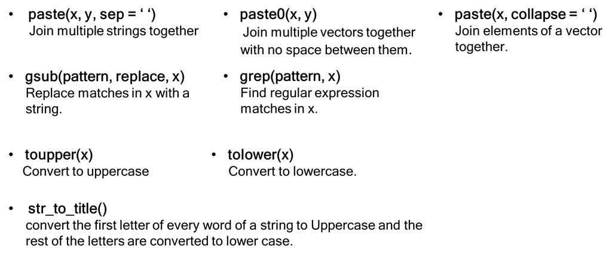

```r
str_1 <- "Hello_"
str_2 <- "World!"
vec <- c(str_1, str_2)
# paste
paste(str_1, str_2, sep = " ")
```

```
## [1] "Hello_ World!"
```

```r
paste(vec, collapse = " ")
```

```
## [1] "Hello_ World!"
```

```r
paste0(str_1, str_2)
```

```
## [1] "Hello_World!"
```

```r
# gsub
gsub("_", "!", str_1)
```

```
## [1] "Hello!"
```

```r
grep("Wo", vec)
```

```
## [1] 2
```

```r
# to
toupper(str_2)
```

```
## [1] "WORLD!"
```

```r
tolower(str_1)
```

```
## [1] "hello_"
```

```r
# str_to_title
str_to_title("r workshop")
```

```
## [1] "R Workshop"
```

### Special Characters

The “\” is a special character in R. If you want to type a slash, you need to put another slash before it. Also, if you want a quotation in your string, you need to put a slash before it.

(Read the [stringr cheatsheet](https://github.com/rstudio/cheatsheets/blob/main/strings.pdf) second page for more information.)

```r
# print("\") ##You will get an error!
slash <- "\\"
slash
```

```
## [1] "\\"
```

```r
quote_str <- "\""
quote_str
```

```
## [1] "\""
```

# Acknowledgement

I would like to thank my supervisor Dr Gregor Reid, Dr Ali Farrokhi, and Tanmaya Atre, for their support and guidance. Also, I would like to thank Reid’s lab members and all of the people who helped me to get through my project.

# Resources

- programiz.com
- sololearn.com
- codeacademy.com
- swcarpentry.github.io
- geeksforgeeks.org
- r-lang.com
- statmethods.net
- techtarget.com
- hbs-rcs.github.io
- datamentor.io
- tutorialspoint.com
- englelab.gatech.edu
- sthda.com
- bookdown.org
- r4ds.had.co.nz